# “**Nepal EarthQuake Disaster (2015)**”

- Kishore Ramakrishnan (Data science enthusiast and an avid sportsmen)

### **Initial cleaning of environment**

cat(“\014”) /*this command is used to clear the console*/  
rm(list = ls()) /*this command is used to clear the environmental variables*/

### **Libraries used**

“aws.s3”, “RCurl”, " polycor“,”doSNOW“,”dplyr“,”caret“,”nnet“,”tidyr“,”data.table“,”ggplot2"

### **Introducing Data**

Based on aspects of building location and construction, the goal of the project is to predict the level of damage to buildings caused by the 2015 Gorkha earthquake in Nepal. The data was collected through surveys by the Central Bureau of Statistics that work under the National Planning Commission Secretariat of Nepal.

This survey is one of the largest post-disaster datasets ever collected, containing valuable information on earthquake impacts, household conditions, and socio-economic-demographic statistics. The data was initially dumped in GitHub and then imported into R and converted into dataframe.

*Target Variable*

| Damage Grade | Count | Description |
| --- | --- | --- |
| 1 | 938 | Low Damage |
| 2 | 5636 | Medium Damage |
| 3 | 3426 | Almost Destroyed |

*Explanatory Variables*

| Column Names | Data Type | Description |
| --- | --- | --- |
| building_id | Integer | Each and every building is given an unique ID |
| geo_level_1_ID, geo_level_2_ID, geo_level_3_ID | Categorical | Geographic region in which building exists from largest(level 1) to sub-region(level 3) |
| count_floors_pre_eq | Integer | Number of floors in the building before earthquake |
| age | Integer | Age of the building |
| area | Integer | Plinth area of the building |
| height | Integer | Height of the building |
| land_surface_condition | Categorical | Surface condition of the land where building was built |
| foundation_type | Categorical | Type of foundation used for the building |
| roof_type | Categorical | Type of roof used while building |
| ground_floor_type | Categorical | type of ground floor |
| other_floor_type | Categorical | Type of construction used in higher floors other than ground floors |
| position | Categorical | position of the building |
| plan_configuration | Categorical | Building plan configuration |
| legal_ownership_status | Binary | Legal ownership status of the land where building was built |
| count_families | Integer | Number of families in the building |
| superstructure_material_type | Categorical | different types of materials used for building to built |
| secondary_use | Categorical | Secondary use of the building |

Data Cleaning of data is done, Now starting the Data mining and Association analysis

### **Association Analysis**

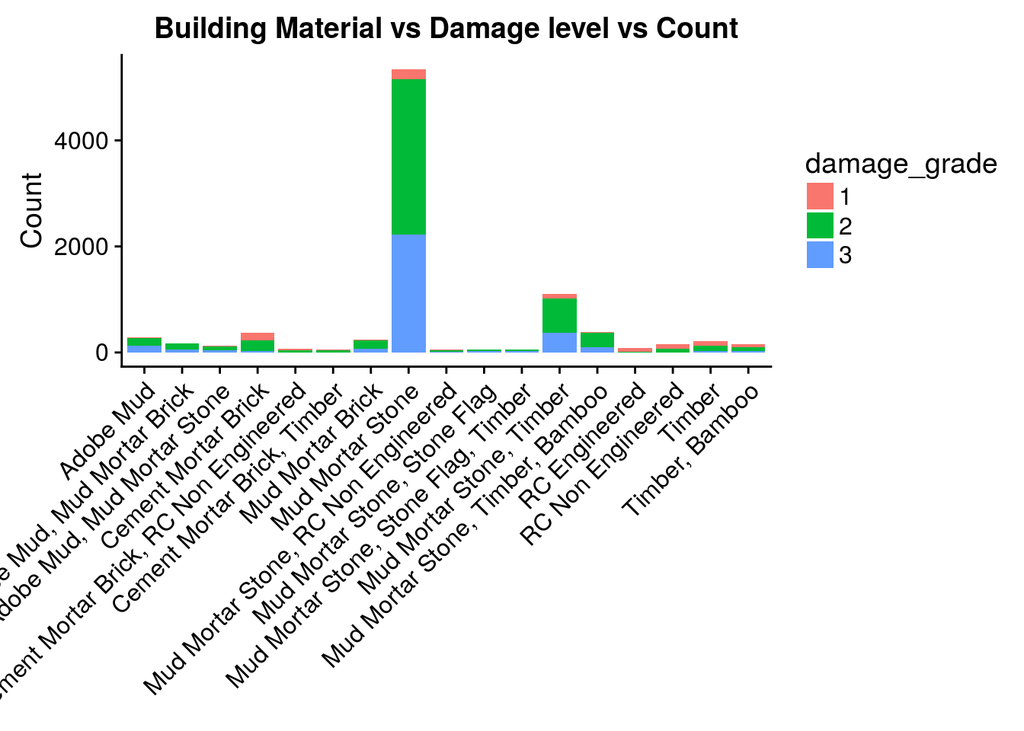

```r
ggplot(data = dt1) + geom_bar(mapping = aes(x = superstructure_Material_Type, fill = damage_grade)) + ggtitle("Building Material vs Damage level vs Count") + xlab("Material Type") + ylab("Count") + theme(axis.title.x = element_blank(), axis.text.x = element_text(angle = 45, hjust = 1))
```

### **Association Analysis in Low damaged dataset**

```
##     items                                     support count
## [1] {land_surface_condition=d502,
##      Secondary_use=No Secondary use at all} 0.7164179   672
## [2] {land_surface_condition=d502}           0.8539446   801
## [3] {Secondary_use=No Secondary use at all} 0.8358209   784
## [4] {roof_type=7e76}                        0.5522388   518
```

```
##      items                                             support count
## [1]  {foundation_type=337f,
##       superstructure_Material_Type=Mud Mortar Stone} 0.5044358  2843
## [2]  {land_surface_condition=d502,
##       roof_type=7e76,
##       Secondary_use=No Secondary use at all}         0.5136622  2895
## [3]  {land_surface_condition=d502,
##       foundation_type=337f,
##       roof_type=7e76}                                0.5250177  2959
## [4]  {foundation_type=337f,
##       roof_type=7e76,
##       Secondary_use=No Secondary use at all}         0.5718595  3223
## [5]  {roof_type=7e76,
##       Secondary_use=No Secondary use at all}         0.6268630  3533
## [6]  {foundation_type=337f,
##       roof_type=7e76}                                0.6469127  3646
## [7]  {land_surface_condition=d502,
##       roof_type=7e76}                                0.5789567  3263
## [8]  {land_surface_condition=d502,
##       foundation_type=337f,
##       Secondary_use=No Secondary use at all}         0.6236693  3515
## [9]  {land_surface_condition=d502,
##       Secondary_use=No Secondary use at all}         0.7260468  4092
## [10] {land_surface_condition=d502,
##       foundation_type=337f}                          0.6978353  3933
## [11] {foundation_type=337f,
##       Secondary_use=No Secondary use at all}         0.7581618  4273
## [12] {Secondary_use=No Secondary use at all}         0.8804116  4962
## [13] {foundation_type=337f}                          0.8537970  4812
## [14] {land_surface_condition=d502}                   0.8204400  4624
## [15] {roof_type=7e76}                                0.7116749  4011
## [16] {superstructure_Material_Type=Mud Mortar Stone} 0.5193400  2927
```

```
##      items                                             support count
## [1]  {land_surface_condition=d502,
##       foundation_type=337f,
##       Secondary_use=No Secondary use at all,
##       superstructure_Material_Type=Mud Mortar Stone} 0.5014594  1718
## [2]  {land_surface_condition=d502,
##       foundation_type=337f,
##       superstructure_Material_Type=Mud Mortar Stone} 0.5426153  1859
## [3]  {land_surface_condition=d502,
##       Secondary_use=No Secondary use at all,
##       superstructure_Material_Type=Mud Mortar Stone} 0.5093403  1745
## [4]  {foundation_type=337f,
##       Secondary_use=No Secondary use at all,
##       superstructure_Material_Type=Mud Mortar Stone} 0.5910683  2025
## [5]  {foundation_type=337f,
##       superstructure_Material_Type=Mud Mortar Stone} 0.6392294  2190
## [6]  {Secondary_use=No Secondary use at all,
##       superstructure_Material_Type=Mud Mortar Stone} 0.6007005  2058
## [7]  {land_surface_condition=d502,
##       superstructure_Material_Type=Mud Mortar Stone} 0.5516637  1890
## [8]  {land_surface_condition=d502,
##       foundation_type=337f,
##       roof_type=7e76,
##       Secondary_use=No Secondary use at all}         0.5347344  1832
## [9]  {land_surface_condition=d502,
##       foundation_type=337f,
##       roof_type=7e76}                                0.5826036  1996
## [10] {land_surface_condition=d502,
##       roof_type=7e76,
##       Secondary_use=No Secondary use at all}         0.5560420  1905
## [11] {foundation_type=337f,
##       roof_type=7e76,
##       Secondary_use=No Secondary use at all}         0.6395213  2191
## [12] {foundation_type=337f,
##       roof_type=7e76}                                0.6967309  2387
## [13] {roof_type=7e76,
##       Secondary_use=No Secondary use at all}         0.6637478  2274
## [14] {land_surface_condition=d502,
##       roof_type=7e76}                                0.6056626  2075
## [15] {land_surface_condition=d502,
##       foundation_type=337f,
##       Secondary_use=No Secondary use at all}         0.7446001  2551
## [16] {land_surface_condition=d502,
##       foundation_type=337f}                          0.8035610  2753
## [17] {land_surface_condition=d502,
##       Secondary_use=No Secondary use at all}         0.7793345  2670
## [18] {foundation_type=337f,
##       Secondary_use=No Secondary use at all}         0.8835377  3027
## [19] {foundation_type=337f}                          0.9532983  3266
## [20] {Secondary_use=No Secondary use at all}         0.9246935  3168
## [21] {land_surface_condition=d502}                   0.8423818  2886
## [22] {roof_type=7e76}                                0.7232925  2478
## [23] {superstructure_Material_Type=Mud Mortar Stone} 0.6500292  2227
```

1. Land surface condition
2. Foundation type
3. Roof type
4. Secondary use of the building
5. Super structure material used in the building

### **Correlation between the Training variables and Target Variable**

```
##                                      [,1]
## geo_level_1_id               -0.064084324
## geo_level_2_id               -0.004755451
## land_surface_condition        0.005962119
## foundation_type              -0.277408237
## roof_type                     0.178646753
## Secondary_use                 0.031208881
## superstructure_Material_Type -0.064098350
```

### **Processed Data**

```
##   building_id geo_level_1_id geo_level_2_id land_surface_condition
## 1           1             18            717                   d502
## 2           2              2            241                   d502
## 3           3              5            119                   d502
##   foundation_type roof_type           Secondary_use
## 1            337f      e0e2 No Secondary use at all
## 2            337f      7e76 No Secondary use at all
## 3            337f      7e76 No Secondary use at all
##   superstructure_Material_Type damage_grade
## 1             Mud Mortar Stone            2
## 2     Mud Mortar Stone, Timber            2
## 3             Mud Mortar Stone            3
```

### **Summary about the Processed data**

```
##   building_id    geo_level_1_id geo_level_2_id land_surface_condition
##  Min.   :    1   0      : 903   0      : 157   2f15: 347
##  1st Qu.: 4999   2      : 860   1      :  99   808e:1342
##  Median : 9964   3      : 843   2      :  94   d502:8311
##  Mean   : 9987   1      : 842   3      :  81
##  3rd Qu.:15045   5      : 751   5      :  75
##  Max.   :19999   4      : 730   8      :  71
##                  (Other):5071   (Other):9423
##  foundation_type roof_type                     Secondary_use
##  337f:8489       67f9: 579   No Secondary use at all  :8914
##  467b: 372       7e76:7007   Agriculture              : 649
##  6c3e: 504       e0e2:2414   Hotel                    : 293
##  858b: 587                   Rental                   :  64
##  bb5f:  48                   Other uses               :  28
##                              Agriculture and Other Use:  24
##                              (Other)                  :  28
##                    superstructure_Material_Type damage_grade
##  Mud Mortar Stone                :5344          1: 938
##  Mud Mortar Stone, Timber        :1103          2:5636
##  Mud Mortar Stone, Timber, Bamboo: 392          3:3426
##  Cement Mortar Brick             : 376
##  Adobe Mud                       : 282
##  Mud Mortar Brick                : 237
##  (Other)                         :2266
```